# DATA ANALYTICS ALL SLIPS

Que: Create ‘sales’ Data set having 5 columns namely: ID, TV, Radio, Newspaper and Sales.(random 500 entries) Build a linear regression model by identifying independent and target variable. Split the variables into training and testing sets. then divide the training and testing sets into a 7:3 ratio, respectively and print them. Build a simple linear regression model.

```python
import pandas as pd
import numpy as np
from sklearn.model_selection import train_test_split
from sklearn.linear_model import LinearRegression
from sklearn.metrics import mean_squared_error, r2_score

np.random.seed(42)

data = {

    'ID':np.arange(1,501),
    'TV':np.random.randint(10,100,500),
    'Radio':np.random.randint(5,50,500),
    'NewsPaper':np.random.randint(1,20,500),
    'Sales':np.random.randint(50,200,500)
}
df=pd.DataFrame(data)

X = df[['TV','Radio','NewsPaper']]
y = df['Sales']

X_train,X_test,y_train,y_test = train_test_split(X,y,test_size=0.3,random_state=42)

print(f"X_train shape : {X_train.shape}")
print(f"X_test shape: {X_test.shape}")
print(f"y_train shape: {y_train.shape}")
print(f"y_test shape: {y_test.shape}")

model = LinearRegression()

model.fit(X_train,y_train)
y_pred = model.predict(X_test)

mse = mean_squared_error(y_test,y_pred)
r2 = r2_score(y_test,y_pred)

print(f"Mean Squared Error:{mse}")
print(f"R-squared:{r2}")
```

```
X_train shape : (350, 3)
X_test shape: (150, 3)
y_train shape: (350,)
y_test shape: (150,)
Mean Squared Error:1903.6799883247752
R-squared:-0.00971782782773567
```

Que: Create ‘User’ Data set having 5 columns namely: User ID, Gender, Age, EstimatedSalary and Purchased. Build a logistic regression model that can predict whether on the given parameter a person will buy a car or not.

```python
import pandas as pd
import numpy as np
from sklearn.model_selection import train_test_split
from sklearn.linear_model import LogisticRegression
from sklearn.metrics import accuracy_score, confusion_matrix

np.random.seed(42)

data = {

    'User ID':np.arange(1,501),
    'Gender':np.random.choice(['Male','Female'],500),
    'Age':np.random.randint(18,60,500),
    'EstimatedSalary':np.random.randint(15000,150000,500),
    'Purchased':np.random.choice([0,1],500)

}

df = pd.DataFrame(data)

df['Gender'] = df['Gender'].map({'Male':0,'Female':1})

X=df[['Gender','Age','EstimatedSalary']]
y = df['Purchased']

X_train, X_test, y_train, y_test = train_test_split(X, y, test_size=0.3,
random_state=42)

model = LogisticRegression()
model.fit(X_train,y_train)

y_pred = model.predict(X_test)

accuracy = accuracy_score(y_test,y_pred)
conf_matrix = confusion_matrix(y_test,y_pred)

print(f"Accuracy:{accuracy}")
print(f"Confusion Matrix:n{conf_matrix}")
```

```
Accuracy:0.56
Confusion Matrix:n[[21 47]
 [19 63]]
```

Que ) Build a simple linear regression model for Fish Species Weight Prediction

```
mean squared error:159.66
R-squared score:0.99
```

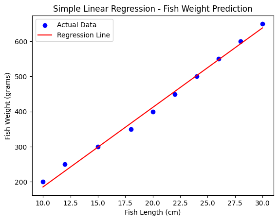

```python
import pandas as pd
import numpy as np
import matplotlib.pyplot as plt
from sklearn.model_selection import train_test_split
from sklearn.linear_model import LinearRegression
from sklearn.metrics import mean_squared_error, r2_score

data = {

    'Length' : [10,12,15,18,20,22,24,26,28,30],
    'Weight' : [200,250,300,350,400,450,500,550,600,650]
}

df = pd.DataFrame(data)

X = df[['Length']]
y = df['Weight']

X_train,X_test,y_train,y_test = train_test_split(X,y,test_size=0.3,random_state=42)

model = LinearRegression()
model.fit(X_train,y_train)

y_pred = model.predict(X_test)

mse = mean_squared_error(y_test,y_pred)
r2 = r2_score(y_test,y_pred)

print(f"mean squared error:{mse:.2f}")
print(f"R-squared score:{r2:.2f}")

plt.scatter(X, y, color='blue', label='Actual Data')
plt.plot(X, model.predict(X), color='red', label='Regression Line')
plt.xlabel("Fish Length (cm)")
plt.ylabel("Fish Weight (grams)")
plt.title("Simple Linear Regression - Fish Weight Prediction")
plt.legend()
plt.show()
```

Que:Create ‘realestate’ Data set having 4 columns namely: ID,flat, houses and purchases (random 500 entries). Build a linear regression model by identifying independent and target variable. Split the variables into training and testing sets and print them. Build a simple linear regression model for predicting purchases.

```python
import pandas as pd
import numpy as np
from sklearn.model_selection import train_test_split
from sklearn.linear_model import LinearRegression
from sklearn.metrics import mean_squared_error, r2_score

np.random.seed(42)

data = {

    'ID':np.arange(1,501),
    'flat': np.random.randint(10,100,500),
    'houses':np.random.randint(5,50,500),
    'purchases':np.random.randint(50,200,500)
}
df =pd.DataFrame(data)

X = df[['flat','houses']]
y=df['purchases']

X_train,X_test,y_train,y_test = train_test_split(X,y,test_size=0.3,random_state=42)

print(f"X_train shape:{X_train.shape}")
print(f"X_test shape:{X_test.shape}")
print(f"y_train shape:{y_train.shape}")
print(f"y_test shape:{y_test.shape}")

model = LinearRegression()
model.fit(X_train,y_train)

y_pred = model.predict(X_test)

mse = mean_squared_error(y_test,y_pred)
r2 = r2_score(y_test,y_pred)

print(f"Mean Squared error:{mse}")
print(f"R-squared:{r2}")
```

```
X_train shape:(350, 2)
X_test shape:(150, 2)
y_train shape:(350,)
y_test shape:(150,)
Mean Squared error:2000.037126687597
R-squared:0.006396252848229755
```

```python
import pandas as pd
from mlxtend.preprocessing import TransactionEncoder
from mlxtend.frequent_patterns import apriori,association_rules

dataset = [

    ['Bread','Milk'],
    ['Bread','Diaper','Beer','Coke'],
    ['Bread','Milk','Diaper','Beer'],
    ['Bread','Milk','Diaper','Coke']
]

te = TransactionEncoder()
te_ary = te.fit(dataset).transform(dataset)
df = pd.DataFrame(te_ary,columns=te.columns_)

print("One -hot encoded DataFrame:")
print(df)

frequent_itemsets = apriori(df,min_support=0.6,use_colnames=True)
print("n Frequent itemset with min_support=0.6:")
print(frequent_itemset)

rules = association_rules(frequent_itemsets,metric="confidence",min_threshold=0.7,num_itemsets=len(dataset))
print("n association rules with min_confidence=0.7:")
print(rules)
```

[output not shown]

```python
import pandas as pd
df = pd.read_csv("influencers.csv")

india_influencers = df[df['country'] == 'India']

top_5 = india_influencers.sort_values(by='followers',ascending=False).head(10)

print(top_5[['channel_info','followers','country']])
```

```
        channel_info followers country
46        nehakakkar     70.4m   India
50      narendramodi     68.9m   India
51        aliaabhatt     68.7m   India
52   deepikapadukone     68.4m   India
57       katrinakaif     66.3m   India
67    jacquelinef143     62.7m   India
78            karolg     55.6m   India
86   beingsalmankhan     53.5m   India
99        kritisanon     50.2m   India
131         varundvn     43.8m   India
```

QUE : Download the Market basket dataset.Write a python program to read the dataset and display its information. Preprocess the data (drop null values etc.) Convert the categorical values into numeric format.Apply the apriori algorithm on the above dataset to generate the frequent itemsets and association rules.

```python
import pandas as pd
from mlxtend.preprocessing import TransactionEncoder
from mlxtend.frequent_patterns import apriori, association_rules

df = pd.read_csv("Market_Basket_analysis.csv")
print("n Dataset Information:")
print(df.info())

df.dropna(inplace=True)

transactions = df.values.tolist()

te = TransactionEncoder()
te_ary = te.fit(transactions).transform(transactions)
df_encoded = pd.DataFrame(te_ary, columns=te.columns_)

frequent_itemsets = apriori(df_encoded, min_support=0.2, use_colnames=True)

rules = association_rules(frequent_itemsets, metric="lift", min_threshold=1.0)

print("\nFrequent Itemsets:")
print(frequent_itemsets)

print("\nAssociation Rules:")
print(rules[['antecedents', 'consequents', 'support', 'confidence', 'lift']])
```

```
n Dataset Information:
<class 'pandas.core.frame.DataFrame'>
RangeIndex: 54 entries, 0 to 53
Data columns (total 8 columns):
 #   Column          Non-Null Count  Dtype
---  ------          --------------  -----
 0   rules           54 non-null     object
 1   support         54 non-null     float64
 2   confidence      54 non-null     float64
 3   lift            54 non-null     float64
 4   count           54 non-null     int64
 5   caterory LHS    54 non-null     object
 6   caterory RHS    54 non-null     object
 7   Combo category  54 non-null     object
dtypes: float64(3), int64(1), object(4)
memory usage: 3.5+ KB
None
```

[output not shown]

Que : Consider any text paragraph. Preprocess the text to remove any special characters and digits. Generate the summary using extractive summarization process.

```python
import re
import nltk
from nltk.tokenize import sent_tokenize
from sklearn.feature_extraction.text import TfidfVectorizer
import numpy as np

nltk.download('punkt')

text = " Hello This is percy"

clean_text = re.sub(r'[^a-zA-Z\s]', '', text)

sentences = sent_tokenize(clean_text)

vectorizer = TfidfVectorizer()
X = vectorizer.fit_transform(sentences)

sentence_scores = np.array(X.sum(axis=1)).flatten()
top_sentence_idx = sentence_scores.argsort()[-2:]

summary = " ".join([sentences[i] for i in sorted(top_sentence_idx)])


print("Original Text:\n", text)
print("\nSummary:\n", summary)
```

[output not shown]

[output cut: 13 more lines]

[output not shown]

QUE : Download the groceries dataset.Write a python program to read the dataset and display its information. Preprocess the data (drop null values etc.)Convert the categorical values into numeric format.Apply the apriori algorithm on the above dataset to generate the frequent itemsets and association rules.

```python
import pandas as pd
from mlxtend.preprocessing import TransactionEncoder
from mlxtend.frequent_patterns import apriori, association_rules

df = pd.read_csv("groceries.csv")
print("n Dataset Information:")
print(df.info())

df.dropna(inplace=True)

transactions = df.values.tolist()

te = TransactionEncoder()
te_ary = te.fit(transactions).transform(transactions)
df_encoded = pd.DataFrame(te_ary, columns=te.columns_)

frequent_itemsets = apriori(df_encoded, min_support=0.2, use_colnames=True)

rules = association_rules(frequent_itemsets, metric="lift", min_threshold=1.0)

print("\nFrequent Itemsets:")
print(frequent_itemsets)

print("\nAssociation Rules:")
print(rules[['antecedents', 'consequents', 'support', 'confidence', 'lift']])
```

```
n Dataset Information:
<class 'pandas.core.frame.DataFrame'>
RangeIndex: 9835 entries, 0 to 9834
Data columns (total 33 columns):
 #   Column   Non-Null Count  Dtype
---  ------   --------------  -----
 0   Item(s)  9835 non-null   int64
 1   Item 1   9835 non-null   object
 2   Item 2   7676 non-null   object
 3   Item 3   6033 non-null   object
 4   Item 4   4734 non-null   object
 5   Item 5   3729 non-null   object
 6   Item 6   2874 non-null   object
 7   Item 7   2229 non-null   object
 8   Item 8   1684 non-null   object
```

[output cut: 27 more lines]

[output not shown]

QUE : Create your own transactions dataset and apply the apriori algorithm on the above dataset to generate the frequent itemsets and association rules. Repeat the process with different min_sup values

```python
import pandas as pd
from mlxtend.preprocessing import TransactionEncoder
from mlxtend.frequent_patterns import apriori, association_rules

transactions = [
    ['Milk', 'Bread', 'Eggs'],
    ['Milk', 'Diaper', 'Beer', 'Eggs'],
    ['Milk', 'Diaper', 'Beer', 'Coke'],
    ['Bread', 'Eggs', 'Milk'],
    ['Bread', 'Diaper', 'Beer', 'Coke'],
    ['Milk', 'Diaper', 'Coke']
]

te = TransactionEncoder()
te_ary = te.fit(transactions).transform(transactions)
df = pd.DataFrame(te_ary, columns=te.columns_)

def apply_apriori(min_sup):
    print(f"\nResults for min_support = {min_sup}:\n")
    frequent_itemsets = apriori(df, min_support=min_sup, use_colnames=True)
    rules = association_rules(frequent_itemsets, metric="lift", min_threshold=1.0)

    print("Frequent Itemsets:\n", frequent_itemsets)
    print("\nAssociation Rules:\n", rules[['antecedents', 'consequents', 'support', 'confidence', 'lift']])


apply_apriori(0.5)
apply_apriori(0.3)
apply_apriori(0.2)
```

```
Results for min_support = 0.5:

Frequent Itemsets:
     support        itemsets
0  0.500000          (Beer)
1  0.500000         (Bread)
2  0.500000          (Coke)
3  0.666667        (Diaper)
4  0.500000          (Eggs)
5  0.833333          (Milk)
6  0.500000  (Beer, Diaper)
7  0.500000  (Coke, Diaper)
8  0.500000  (Diaper, Milk)
9  0.500000    (Eggs, Milk)

```

[output cut: 122 more lines]

Que: Create ‘sales’ Data set having 5 columns namely: ID, TV, Radio, Newspaper and Sales.(random 500 entries) Build a linear regression model by identifying independent and target variable. Split the variables into training and testing sets. then divide the training and testing sets into a 7:3 ratio, respectively and print them. Build a simple linear regression model.

```python
import pandas as pd
import numpy as np
from sklearn.model_selection import train_test_split
from sklearn.linear_model import LinearRegression
from sklearn.metrics import mean_squared_error, r2_score

np.random.seed(42)

data = {

    'ID':np.arange(1,501),
    'TV':np.random.randint(10,100,500),
    'Radio':np.random.randint(5,50,500),
    'NewsPaper':np.random.randint(1,20,500),
    'Sales':np.random.randint(50,200,500)
}
df=pd.DataFrame(data)

X = df[['TV','Radio','NewsPaper']]
y = df['Sales']

X_train,X_test,y_train,y_test = train_test_split(X,y,test_size=0.3,random_state=42)

print(f"X_train shape : {X_train.shape}")
print(f"X_test shape: {X_test.shape}")
print(f"y_train shape: {y_train.shape}")
print(f"y_test shape: {y_test.shape}")

model = LinearRegression()

model.fit(X_train,y_train)
y_pred = model.predict(X_test)

mse = mean_squared_error(y_test,y_pred)
r2 = r2_score(y_test,y_pred)

print(f"Mean Squared Error:{mse}")
print(f"R-squared:{r2}")
```

```
X_train shape : (350, 3)
X_test shape: (150, 3)
y_train shape: (350,)
y_test shape: (150,)
Mean Squared Error:1903.6799883247752
R-squared:-0.00971782782773567
```

QUE : Create ‘realestate’ Data set having 4 columns namely: ID,flat, houses and purchases (random 500 entries). Build a linear regression model by identifying independent and target variable. Split the variables into training and testing sets and print them. Build a simple linear regression model for predicting purchases.

```python
import pandas as pd
import numpy as np
from sklearn.model_selection import train_test_split
from sklearn.linear_model import LinearRegression
from sklearn.metrics import mean_squared_error, r2_score

np.random.seed(42)

data = {

    'ID':np.arange(1,501),
    'flat': np.random.randint(10,100,500),
    'houses':np.random.randint(5,50,500),
    'purchases':np.random.randint(50,200,500)
}
df =pd.DataFrame(data)

X = df[['flat','houses']]
y=df['purchases']

X_train,X_test,y_train,y_test = train_test_split(X,y,test_size=0.3,random_state=42)

print(f"X_train shape:{X_train.shape}")
print(f"X_test shape:{X_test.shape}")
print(f"y_train shape:{y_train.shape}")
print(f"y_test shape:{y_test.shape}")

model = LinearRegression()
model.fit(X_train,y_train)

y_pred = model.predict(X_test)

mse = mean_squared_error(y_test,y_pred)
r2 = r2_score(y_test,y_pred)

print(f"Mean Squared error:{mse}")
print(f"R-squared:{r2}")
```

```
X_train shape:(350, 2)
X_test shape:(150, 2)
y_train shape:(350,)
y_test shape:(150,)
Mean Squared error:2000.037126687597
R-squared:0.006396252848229755
```

```python
import pandas as pd
from mlxtend.preprocessing import TransactionEncoder
from mlxtend.frequent_patterns import apriori,association_rules

dataset = [

    ['Bread','Milk'],
    ['Bread','Diaper','Beer','Coke'],
    ['Bread','Milk','Diaper','Beer'],
    ['Bread','Milk','Diaper','Coke']
]

te = TransactionEncoder()
te_ary = te.fit(dataset).transform(dataset)
df = pd.DataFrame(te_ary,columns=te.columns_)

print("One -hot encoded DataFrame:")
print(df)

frequent_itemsets = apriori(df,min_support=0.6,use_colnames=True)
print("n Frequent itemset with min_support=0.6:")
print(frequent_itemset)

rules = association_rules(frequent_itemsets,metric="confidence",min_threshold=0.7,num_itemsets=len(dataset))
print("n association rules with min_confidence=0.7:")
print(rules)
```

[output not shown]

QUE : Create ‘User’ Data set having 5 columns namely: User ID, Gender, Age, EstimatedSalary and Purchased. Build a logistic regression model that can predict whether on the given parameter a person will buy a car or not.

```python
import pandas as pd
import numpy as np
from sklearn.model_selection import train_test_split
from sklearn.linear_model import LogisticRegression
from sklearn.metrics import accuracy_score, confusion_matrix

np.random.seed(42)

data = {

    'User ID':np.arange(1,501),
    'Gender':np.random.choice(['Male','Female'],500),
    'Age':np.random.randint(18,60,500),
    'EstimatedSalary':np.random.randint(15000,150000,500),
    'Purchased':np.random.choice([0,1],500)

}

df = pd.DataFrame(data)

df['Gender'] = df['Gender'].map({'Male':0,'Female':1})

X=df[['Gender','Age','EstimatedSalary']]
y = df['Purchased']

X_train, X_test, y_train, y_test = train_test_split(X, y, test_size=0.3,
random_state=42)

model = LogisticRegression()
model.fit(X_train,y_train)

y_pred = model.predict(X_test)

accuracy = accuracy_score(y_test,y_pred)
conf_matrix = confusion_matrix(y_test,y_pred)

print(f"Accuracy:{accuracy}")
print(f"Confusion Matrix:n{conf_matrix}")
```

```
Accuracy:0.56
Confusion Matrix:n[[21 47]
 [19 63]]
```

```python
import pandas as pd
from mlxtend.preprocessing import TransactionEncoder
from mlxtend.frequent_patterns import apriori,association_rules

dataset = [

    ['Bread','Milk'],
    ['Bread','Diaper','Beer','Coke'],
    ['Bread','Milk','Diaper','Beer'],
    ['Bread','Milk','Diaper','Coke']
]

te = TransactionEncoder()
te_ary = te.fit(dataset).transform(dataset)
df = pd.DataFrame(te_ary,columns=te.columns_)

print("One -hot encoded DataFrame:")
print(df)

frequent_itemsets = apriori(df,min_support=0.6,use_colnames=True)
print("n Frequent itemset with min_support=0.6:")
print(frequent_itemset)

rules = association_rules(frequent_itemsets,metric="confidence",min_threshold=0.7,num_itemsets=len(dataset))
print("n association rules with min_confidence=0.7:")
print(rules)
```

[output not shown]